# Równanie Schrödingera - Prezentacja implementacji numerycznej

*Julia Zalewska, Oliwia Marut, Natalia Chmiel*

cd Numerical-computations-project jupyter nbconvert codes.ipynb --to slides --post serve

# Architektura pakietu

Prezentowane kody opierają się na stworzonym przez nas pakiecie w języku Julia. Główny plik modułu `SchrodingerSolver.jl` spina cały projekt w spójną całość.

```julia
module SchrodingerSolver
    using LinearAlgebra
    include("SchrodingerSolver/src/fdm.jl")
    include("SchrodingerSolver/src/numerov.jl")
    export solve_FDM, solve_Numerov, E_analytic
end

using .SchrodingerSolver
```

## Metoda Różnic Skończonych (FDM) - Implementacja i Wykresy

```julia
using LinearAlgebra
using SparseArrays
using Plots
```

Poniższa funkcja buduje macierz Hamiltona dla wektora potencjału `V` rozłożonego na siatce przestrzennej `x` i rozwiązuje problem własny.

```julia
function solve_FDM(V::Vector{Float64},x::Vector{Float64}, m::Float64,
    planck::Float64; n_states::Int=3)

    N = length(x)
    dx = x[2] - x[1]

    # Współczynnik przy drugiej pochodnej
    C = planck^2 / (2.0 * m * dx^2)

    # Przekątna główna i poboczna
    main_diag = V .+ (2.0 * C)
    under_diag = fill(-C, N - 1)

    # Utworzenie rzadkiej macierzy trójprzekątnej
    H = SymTridiagonal(main_diag, under_diag)

    # Rozwiązanie problemu własnego
    eigenvalues, eigenvectors = eigen(H)

    # Wybór n_states najniższych stanów
    E = eigenvalues[1:n_states]
    psi = eigenvectors[:, 1:n_states]

    # Normalizacja funkcji falowych w przestrzeni ciągłej
    psi = psi ./ sqrt(dx)

    return E, psi
end
```

```
solve_FDM (generic function with 1 method)
```

### Testy i wizualizacje wyników dla różnych potencjałów

## Wizualizacja wyników (Wykresy)

Poniżej prezentujemy wyniki działania metody **Różnic Skończonych (FDM)** dla kwantowego oscylatora harmonicznego ($V(x) = \frac{1}{2} k x^2$). Na wykresie nakładamy funkcje falowe na odpowiadające im poziomy energii.

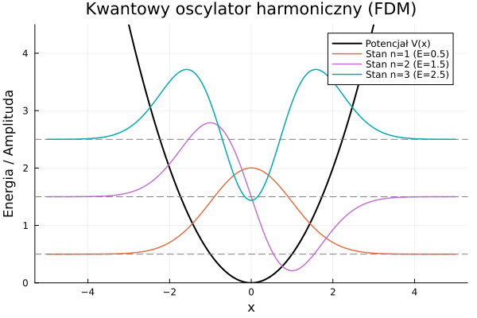

```julia
using Plots
using .SchrodingerSolver

x_plot = collect(range(-5.0, 5.0, length=1000))
m_plot = 1.0
planck_plot = 1.0
k_plot = 1.0

# Definicja potencjału (Oscylator harmoniczny)
V_plot = 0.5 .* k_plot .* x_plot.^2

# Rozwiązanie równania metodą FDM
energies, wavefuncs = solve_FDM(V_plot, x_plot, m_plot, planck_plot)

p = plot(x_plot, V_plot, label="Potencjał V(x)", linewidth=2, color=:black,
         xlabel="x", ylabel="Energia / Amplituda",
         title="Kwantowy oscylator harmoniczny (FDM)", ylims=(0, energies[3] + 2.0))

# Dodanie 3 najniższych stanów (funkcje falowe przesunięte o wartość energii E)
for i in 1:3
    plot!(p, x_plot, energies[i] .+ 2.0 .* wavefuncs[:, i],
          label="Stan n=$i (E=$(round(energies[i], digits=2)))", linewidth=1.5)

    hline!(p, [energies[i]], linestyle=:dash, color=:gray, label="")
end

display(p)
```

## Analiza wydajności

Sprawdzamy czas wykonania oraz zużycie pamięci dla metody **FDM**. Wykorzystujemy pakiet `@benchmark`, aby ocenić, jak dobrze nasza metoda radzi sobie dla siatki o rozmiarze $N=1000$.

```julia
using BenchmarkTools

x_bench = collect(range(-5.0, 5.0, length=1000))
V_bench = zeros(length(x_bench))
m_bench = 1.0
planck_bench = 1.0

println("Testowanie metody FDM dla N = 1000")
@benchmark solve_FDM($V_bench, $x_bench, $m_bench, $planck_bench)
```

```
Testowanie metody FDM dla N = 1000
```

```
BenchmarkTools.Trial: 114 samples with 1 evaluation per sample.
 Range (min … max):  39.167 ms … 248.829 ms  ┊ GC (min … max): 0.00% … 83.67%
 Time  (median):     41.414 ms               ┊ GC (median):    1.79%
 Time  (mean ± σ):   44.106 ms ±  19.784 ms  ┊ GC (mean ± σ):  6.48% ±  9.06%

   ▅█▇
  █████▅▆▃▄▅▄▃▃▁▁▃▁▁▁▁▁▁▁▁▁▁▁▁▁▁▁▁▁▁▁▁▁▁▁▁▁▁▁▁▁▁▁▁▁▁▁▁▁▁▁▁▁▁▁▃ ▃
  39.2 ms         Histogram: frequency by time         80.5 ms <

 Memory estimate: 7.95 MiB, allocs estimate: 39.
```

## Przypadki brzegowe i błędy - co może pójść nie tak?

Nasza funkcja zakłada, że użytkownik poda sensowne dane fizyczne. Co jednak w sytuacji, gdy wektor potencjału `V` nie będzie odpowiadał długością wektorowi siatki `x`? Wywołajmy celowy błąd (DimensionMismatch), aby zobaczyć, jak zachowa się program.

```julia
# Tworzymy wektor x o długości 1000
x_bad = collect(range(-5.0, 5.0, length=1000))

# Tworzymy wektor V o długości tylko 500
V_bad = zeros(500)

println("Próba uruchomienia FDM dla niezgodnych wymiarów...")
solve_FDM(V_bad, x_bad, 1.0, 1.0)
```

```
Próba uruchomienia FDM dla niezgodnych wymiarów...
```

```
DimensionMismatch: subdiagonal has wrong length. Has length 999, but should be either 499 or 500.

Stacktrace:
 [1] SymTridiagonal
   @ C:\Users\nachm\.julia\juliaup\julia-1.12.5+0.x64.w64.mingw32\share\julia\stdlib\v1.12\LinearAlgebra\src\tridiag.jl:12 [inlined]
 [2] SymTridiagonal
   @ C:\Users\nachm\.julia\juliaup\julia-1.12.5+0.x64.w64.mingw32\share\julia\stdlib\v1.12\LinearAlgebra\src\tridiag.jl:71 [inlined]
 [3] SymTridiagonal
   @ C:\Users\nachm\.julia\juliaup\julia-1.12.5+0.x64.w64.mingw32\share\julia\stdlib\v1.12\LinearAlgebra\src\tridiag.jl:70 [inlined]
 [4] solve_FDM(V::Vector{Float64}, x::Vector{Float64}, m::Float64, planck::Float64; n_states::Int64)
   @ Main .\In[3]:15
 [5] solve_FDM(V::Vector{Float64}, x::Vector{Float64}, m::Float64, planck::Float64)
   @ Main .\In[3]:1
 [6] top-level scope
   @ In[6]:8
 [7] eval(m::Module, e::Any)
   @ Core .\boot.jl:489
```